# Balance responses in MS

J. Lucas McKay

Daniel S. Peterson

04 February 2020

# Introduction

This document describes the analysis of standing balance responses in people with and without multiple sclerosis (MS) using wavelet-based functional ANOVA (wfANOVA<sup>1</sup>). MS has profound effects on balance,<sup>2</sup> including altering protective stepping behaviors.<sup>3</sup> The main objective of this study was to examine the impact of MS on the pattern of magnitude and timing of muscle activation during feet-in-place balance responses.

# Methods

## Data sources

This study analyzed existing electromyographic recordings during balance responses in people with and without MS. An earlier analysis of a subset of these records is available.<sup>3</sup> Inclusion criteria for MS participants were as follows: diagnosis of MS by a MS neurologist and no relapses within 60 days. Inclusion criteria for all participants included ability to walk 25 ft (7.6 m) without an assistive device, and no other known biomechanical or neurologic conditions affecting stepping or balance.

## Assessment protocol

Complete details of the assessment protocol are avaialble in an earlier report.<sup>4</sup> During each asssessment, subjects stood with arms folded across the chest, eyes open, with their feet at a fixed heel-to-heel distance of 10 cm on a set of 2 custom hydraulic force platforms that translated either forward or backward (Figure 1). In this study, “perturbation direction” refers to the direction of postural sway caused by the surface translation. Therefore, a backward perturbation refers to forward movement of the support surface causing backward body sway and the activation of tibialis anterior (TA), whereas forward perturbations refer to backward translation of the support surface causing forward body sway and the activation of medial gastrocnemius (MG). Six perturbations were delivered, three forward, followed by three backward. Peak platform displacement was 4 cm, at a rate of 15 cm/s, which elicited feet-in-place balance corrections without stepping.

## Electromyography

Surface electromyography was recorded with pairs 2.5-cm<sup>2</sup> surface electrodes placed approximately 2 cm apart, with a ground electrode on the lateral condyle. The activity of tibialis anterior (TA) and medial gastrocnemius (MG) were recorded. For this analysis, we considered only the activity of tibialis anterior of the right leg.

[figure not shown]

Figure 1: Perturbation directions used in testing protocol.

## Data processing

Each individual EMG record was registered to the onset of treadmill motion and resampled to a common sample rate (1 kHz), and processed (high-pass, 35 Hz, de- mean, rectify, low-pass, 40 Hz) as in previous studies.<sup>5,6</sup> Recorded EMG records were visualized stratified by disease state and perturbation direction (Figure 2).

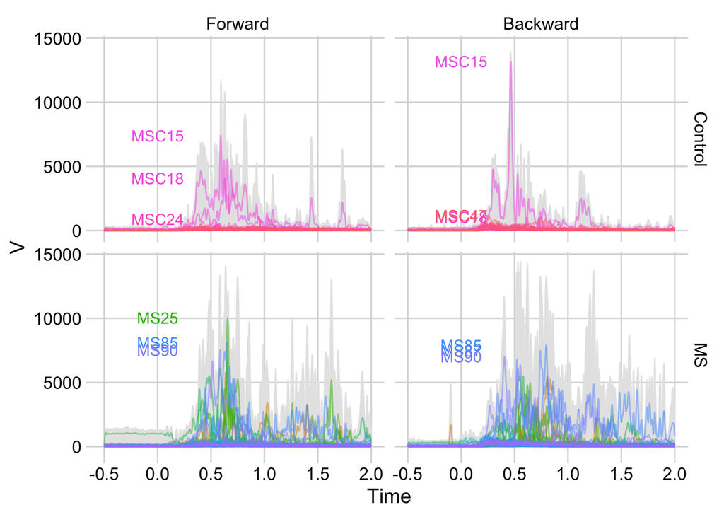

Figure 2: EMG traces stratified by perturbation direction and study group, prior to normalization. Gray traces represent individual trials. Colors represent averages of individual participants.

By visual inspection, there were some gross magnitude differences in recorded EMG levels between the MS and control groups, with higher EMG levels overall in the MS group. EMG levels in most control participants (with the exception of MSC15 and MSC18) were generally roughly an order of magnitude lower than levels in MS participants. This number is difficult to interpret, as it can reflect a large number of biological and methodological factors, so that increased absolute level among MS could reflect increased muscle activation or completely unrelated factors. EMG levels were therefore normalized to the maximum values obtained in a 1 second window after perturbation onset after averaging across like trials (Table 1).

Table 1: Maximum EMG levels.

| Perturbation Direction | Group | Mean | SD | Max |
| --- | --- | --- | --- | --- |
| Forward | Control | 587 | 1286 | 7410 |
| Forward | MS | 882 | 1694 | 10031 |
| Backward | Control | 794 | 2047 | 13175 |
| Backward | MS | 935 | 1489 | 7901 |

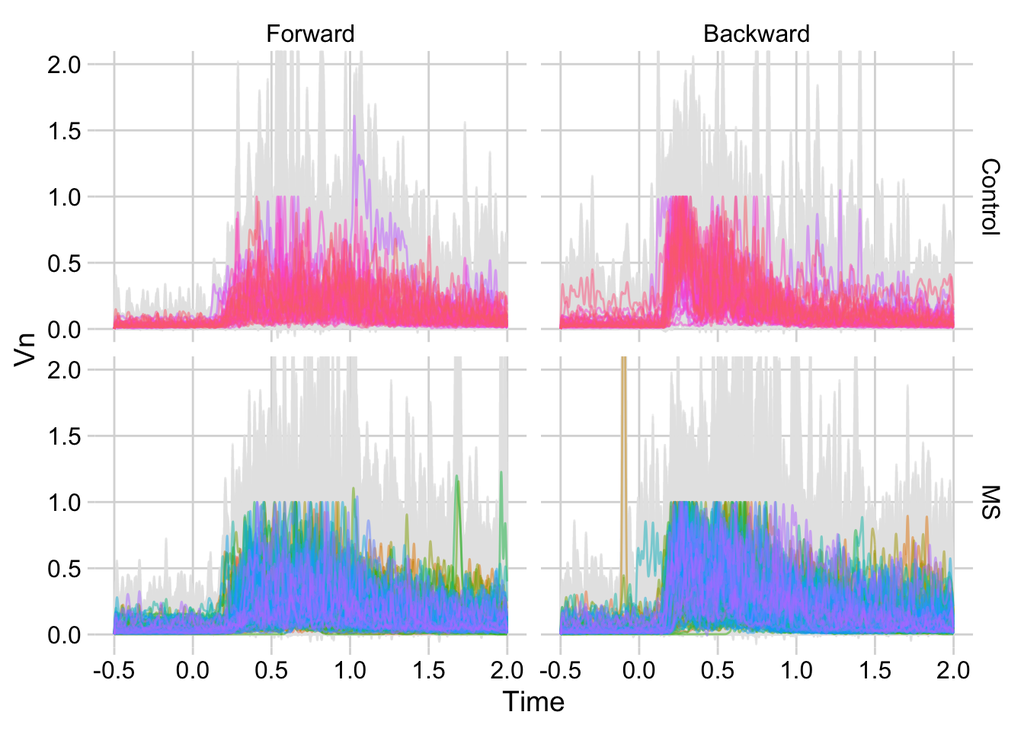

Figure 3: EMG traces stratified by perturbation direction and study group, after normalization. Colors represent averages for individual participants.

# Results

## Demographic and clinical characteristics

Demographic and clinical characteristics of the study population are summarized in Table 2.

Table 2: Clinical and demographic features of the study population.

| Sex | Control | MS | Total |
| --- | --- | --- | --- |
| F | 34 | 91 | 125 |
| M | 5 | 25 | 30 |

# Discussion

### Funding sources and conflict of interest

This study was supported in part by National Institutes of Health grant K25HD086276. The authors report no conflict of interest related to this study.

### Financial disclosures for the previous 12 months

Dr. McKay has received research funding or support from the National Institutes of Health. Dr. McKay has received consulting fees from BioCircuit Technologies.

# References

1. McKay, J. L., Welch, T. D. J., Vidakovic, B. & Ting, L. H. Statistically significant contrasts between EMG waveforms revealed using wavelet-based functional ANOVA. *Journal of Neurophysiology* **109**, 591–602 (2013).

2. Van Liew, C., Dibble, L. E., Hunt, G. R., Foreman, K. B. & Peterson, D. S. Protective stepping in multiple sclerosis: Impacts of a single session of in-place perturbation practice. *Multiple Sclerosis and Related Disorders* **30**, 17–24 (2019).

3. Peterson, D. S., Huisinga, J. M., Spain, R. I. & Horak, F. B. Characterization of Compensatory Stepping in People With Multiple Sclerosis. *Archives of Physical Medicine and Rehabilitation* **97**, 513–521 (2016).

4. Huisinga, J. M., St George, R. J., Spain, R., Overs, S. & Horak, F. B. Postural Response Latencies Are Related to Balance Control During Standing and Walking in Patients With Multiple Sclerosis. *Archives of Physical Medicine and Rehabilitation* **95**, 1390–1397 (2014).

5. Lang, K. C., Hackney, M. E., Ting, L. H. & McKay, J. L. Antagonist muscle activity during reactive balance responses is elevated in Parkinson’s disease and in balance impairment. *PLOS ONE* **14**, e0211137 (2019).

6. McKay, J., Ting, L. & Hackney, M. Balance, body motion, and muscle activity after high-volume short-term dance-based rehabilitation in persons with Parkinson disease: A pilot study. *J Neurol Phys Ther* **40**, 257–68 (2016).